# NDBC Salinity Time Series

Per-buoy salinity from the USF MBON Grafana dashboard

```r
library(dplyr)
library(ggplot2)
library(htmltools)
library(httr2)

source("R/plot_grafana_salinity_ts.R")

ndbc_stations <- list(
  list(name = "bkyf1", long_name = "Buoy_Key"),
  list(name = "bnkf1", long_name = "Butternut_Kay"),
  list(name = "bobf1", long_name = "Bob_Allen_Key"),
  list(name = "bwsf1", long_name = "Blackwater_Sound"),
  list(name = "dkkf1", long_name = "Duck_Key"),
  list(name = "gbtf1", long_name = "Garfield_Bight"),
  list(name = "hcef1", long_name = "Highway_Creek"),
  list(name = "jbyf1", long_name = "Joe_Bay"),
  list(name = "jkyf1", long_name = "Johnson_Key"),
  list(name = "lbsf1", long_name = "Little_Blackwater_Sound"),
  list(name = "lmdf1", long_name = "Little_Madeira_Bay"),
  list(name = "lrkf1", long_name = "Little_Rabbit_Key"),
  list(name = "lsnf1", long_name = "Long_Sound"),
  list(name = "mdkf1", long_name = "Middle_Key"),
  list(name = "mukf1", long_name = "Murray_Key"),
  list(name = "pkyf1", long_name = "Peterson_Key"),
  list(name = "tbyf1", long_name = "Terrapin_Bay"),
  list(name = "thrf1", long_name = "Thursday_Point"),
  list(name = "wrbf1", long_name = "Whipray_Basin")
)

from_ms <- GRAFANA_DEFAULT_FROM
to_ms <- GRAFANA_DEFAULT_TO

salinity_ts <- fetch_grafana_salinity_timeseries(
  from = from_ms,
  to = to_ms
)

report_time <- format(Sys.time(), "%Y-%m-%d %H:%M %Z")
range_start <- format(
  as.POSIXct(as.numeric(from_ms) / 1000, origin = "1970-01-01", tz = "UTC"),
  "%Y-%m-%d"
)
range_end <- format(
  as.POSIXct(as.numeric(to_ms) / 1000, origin = "1970-01-01", tz = "UTC"),
  "%Y-%m-%d"
)
```

Each panel below matches **Grafana panel 33** (*In-situ salinity (psu) at ~1m depth from $Buoy*) on the [USF MBON South Florida Salinity dashboard](https://mbon-dashboards.marine.usf.edu/d/cfraol6xev5kwd/south-florida-salinity?orgId=1&from=1720965498428&to=1784037498428&var-metric=mean&viewPanel=panel-33). Time series are queried from the dashboard’s InfluxDB datasource via the Grafana `/api/ds/query` endpoint, using the same query and time range as the dashboard link you provided.

**Report generated:** 2026-07-14 10:49 EDT  
**Time range:** 2024-07-14 to 2026-07-14 UTC  
**Stations plotted:** 19

Dashed lines mark the same low (25 PSU) and high (35 PSU) thresholds used on the Salinity Gauges page.

## Buoy panels

```r
if (nrow(salinity_ts) == 0) {
  stop("No salinity time series returned from the Grafana datasource.")
}

htmltools::tagList(
  plot_grafana_salinity_panels(
    ndbc_stations,
    salinity_ts,
    from = from_ms,
    to = to_ms
  )
)
```

[Open Grafana panel](https://mbon-dashboards.marine.usf.edu/d-solo/cfraol6xev5kwd/south-florida-salinity?orgId=1&panelId=33&var-metric=mean&var-Buoy=Buoy_Key%20%28bky%29&from=1720965498428&to=1784037498428)

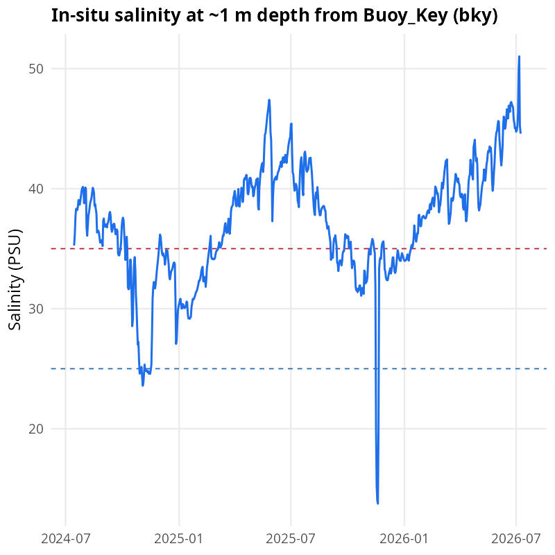

[Open Grafana panel](https://mbon-dashboards.marine.usf.edu/d-solo/cfraol6xev5kwd/south-florida-salinity?orgId=1&panelId=33&var-metric=mean&var-Buoy=Butternut_Kay%20%28bnk%29&from=1720965498428&to=1784037498428)

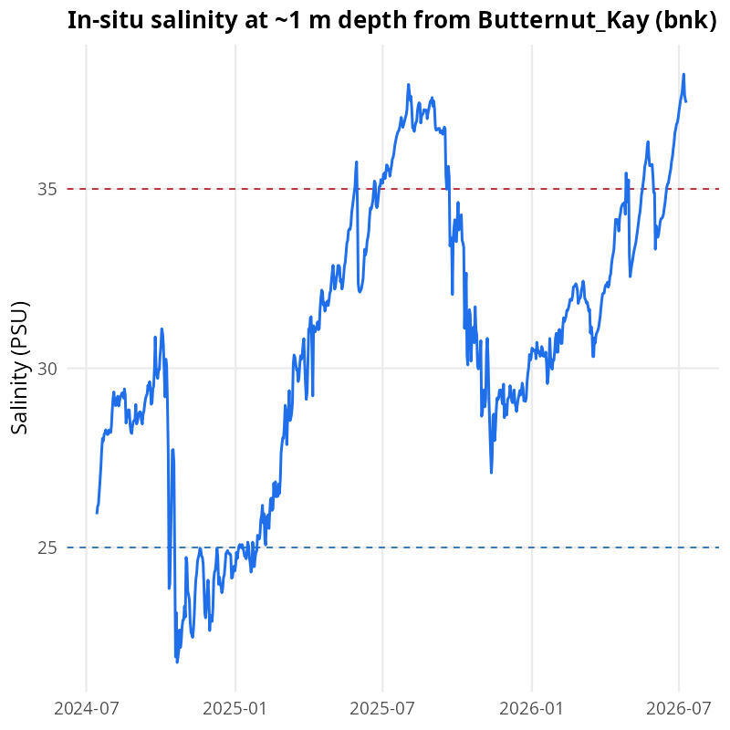

[Open Grafana panel](https://mbon-dashboards.marine.usf.edu/d-solo/cfraol6xev5kwd/south-florida-salinity?orgId=1&panelId=33&var-metric=mean&var-Buoy=Bob_Allen_Key%20%28bob%29&from=1720965498428&to=1784037498428)

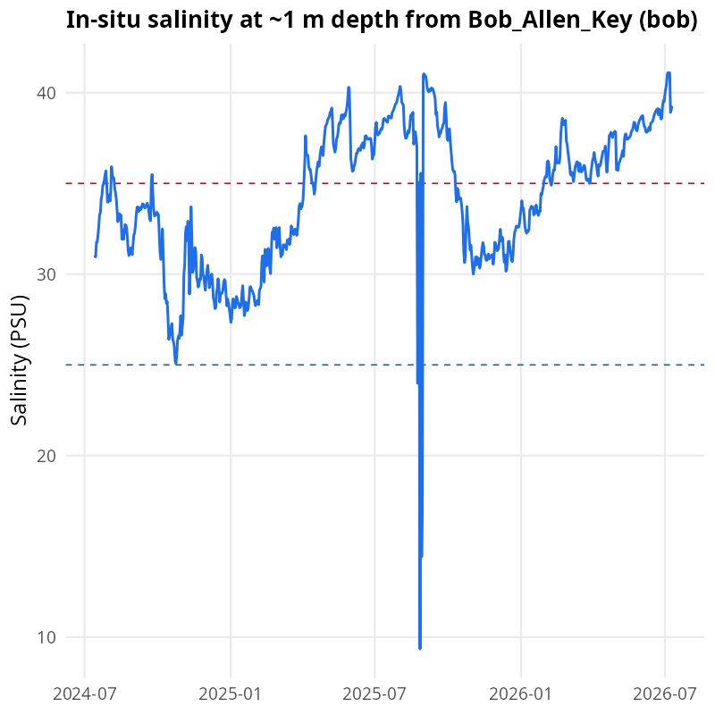

[Open Grafana panel](https://mbon-dashboards.marine.usf.edu/d-solo/cfraol6xev5kwd/south-florida-salinity?orgId=1&panelId=33&var-metric=mean&var-Buoy=Blackwater_Sound%20%28bws%29&from=1720965498428&to=1784037498428)

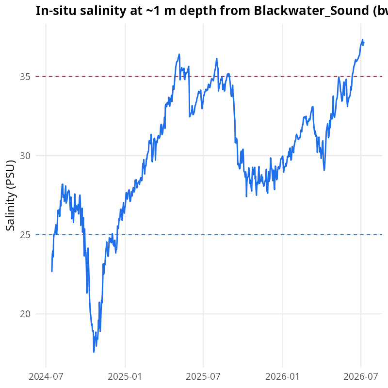

[Open Grafana panel](https://mbon-dashboards.marine.usf.edu/d-solo/cfraol6xev5kwd/south-florida-salinity?orgId=1&panelId=33&var-metric=mean&var-Buoy=Duck_Key%20%28dkk%29&from=1720965498428&to=1784037498428)

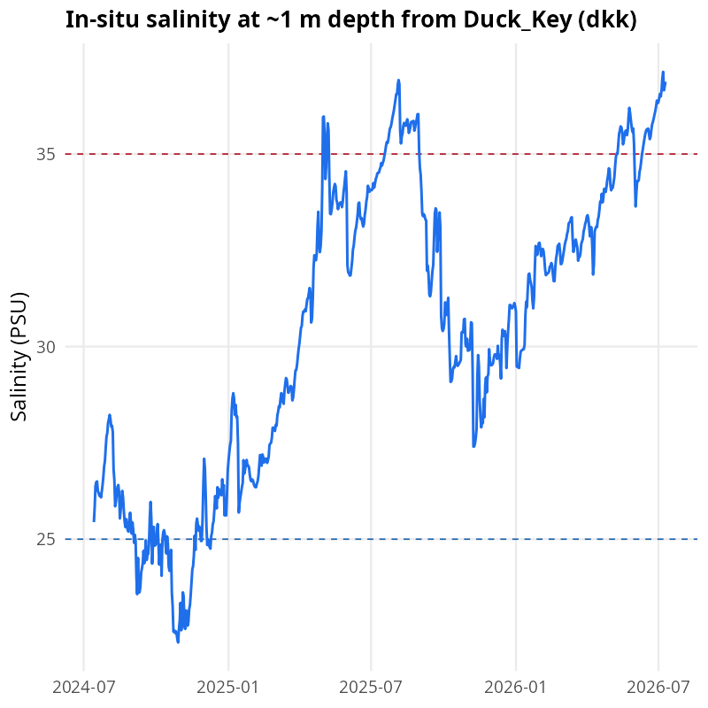

[Open Grafana panel](https://mbon-dashboards.marine.usf.edu/d-solo/cfraol6xev5kwd/south-florida-salinity?orgId=1&panelId=33&var-metric=mean&var-Buoy=Garfield_Bight%20%28gbt%29&from=1720965498428&to=1784037498428)

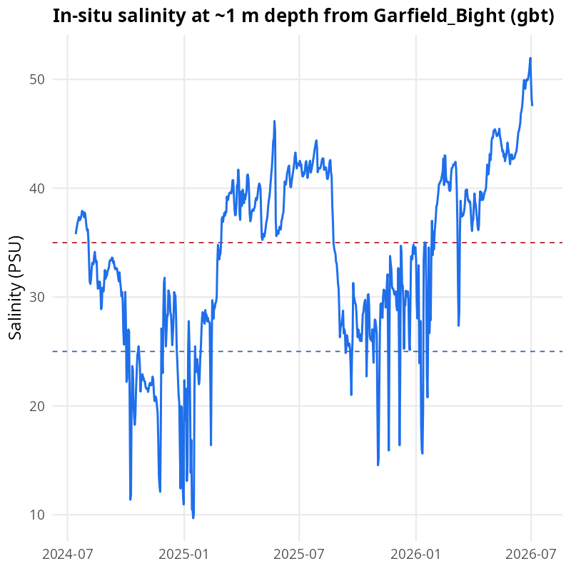

[Open Grafana panel](https://mbon-dashboards.marine.usf.edu/d-solo/cfraol6xev5kwd/south-florida-salinity?orgId=1&panelId=33&var-metric=mean&var-Buoy=Highway_Creek%20%28hce%29&from=1720965498428&to=1784037498428)

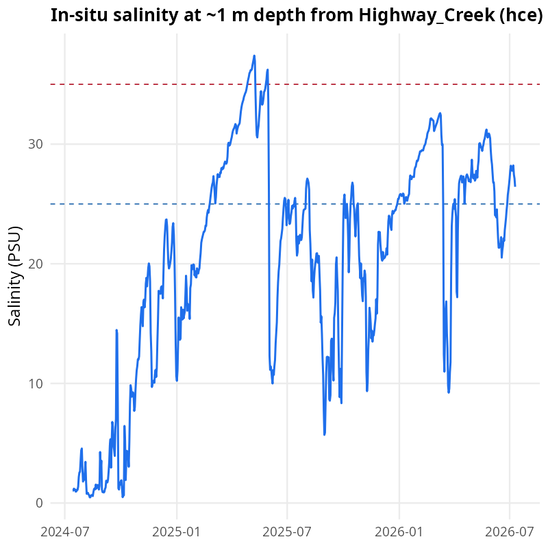

[Open Grafana panel](https://mbon-dashboards.marine.usf.edu/d-solo/cfraol6xev5kwd/south-florida-salinity?orgId=1&panelId=33&var-metric=mean&var-Buoy=Joe_Bay%20%28jby%29&from=1720965498428&to=1784037498428)

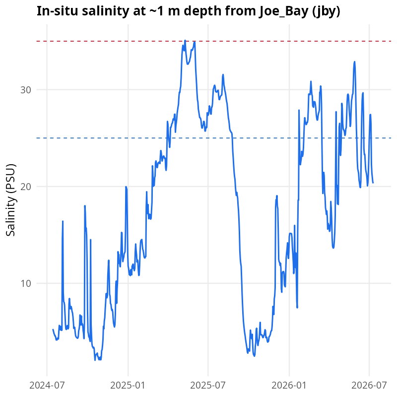

[Open Grafana panel](https://mbon-dashboards.marine.usf.edu/d-solo/cfraol6xev5kwd/south-florida-salinity?orgId=1&panelId=33&var-metric=mean&var-Buoy=Johnson_Key%20%28jky%29&from=1720965498428&to=1784037498428)

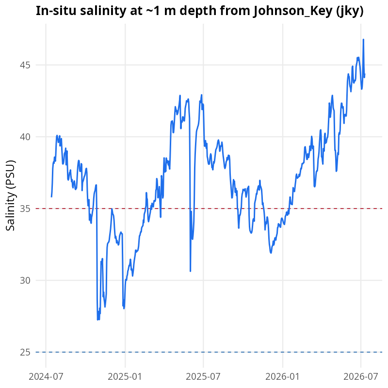

[Open Grafana panel](https://mbon-dashboards.marine.usf.edu/d-solo/cfraol6xev5kwd/south-florida-salinity?orgId=1&panelId=33&var-metric=mean&var-Buoy=Little_Blackwater_Sound%20%28lbs%29&from=1720965498428&to=1784037498428)

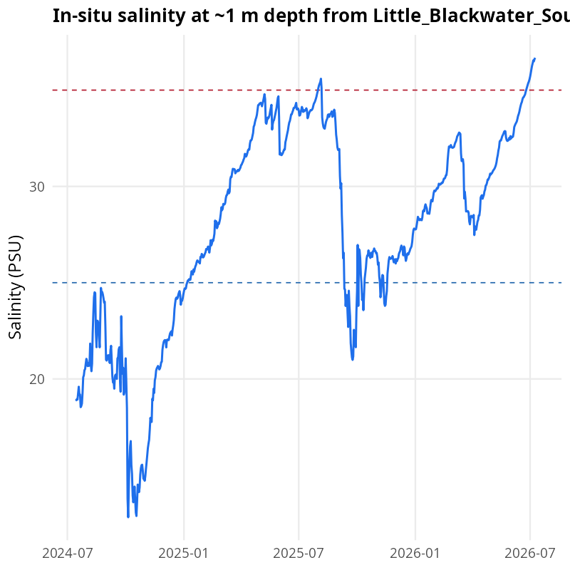

[Open Grafana panel](https://mbon-dashboards.marine.usf.edu/d-solo/cfraol6xev5kwd/south-florida-salinity?orgId=1&panelId=33&var-metric=mean&var-Buoy=Little_Madeira_Bay%20%28lmd%29&from=1720965498428&to=1784037498428)

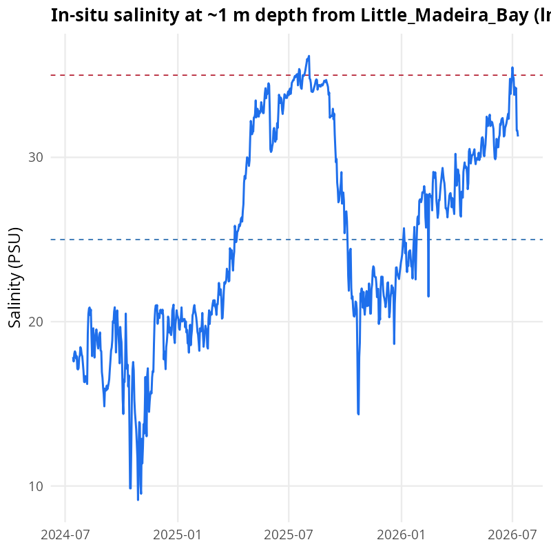

[Open Grafana panel](https://mbon-dashboards.marine.usf.edu/d-solo/cfraol6xev5kwd/south-florida-salinity?orgId=1&panelId=33&var-metric=mean&var-Buoy=Little_Rabbit_Key%20%28lrk%29&from=1720965498428&to=1784037498428)

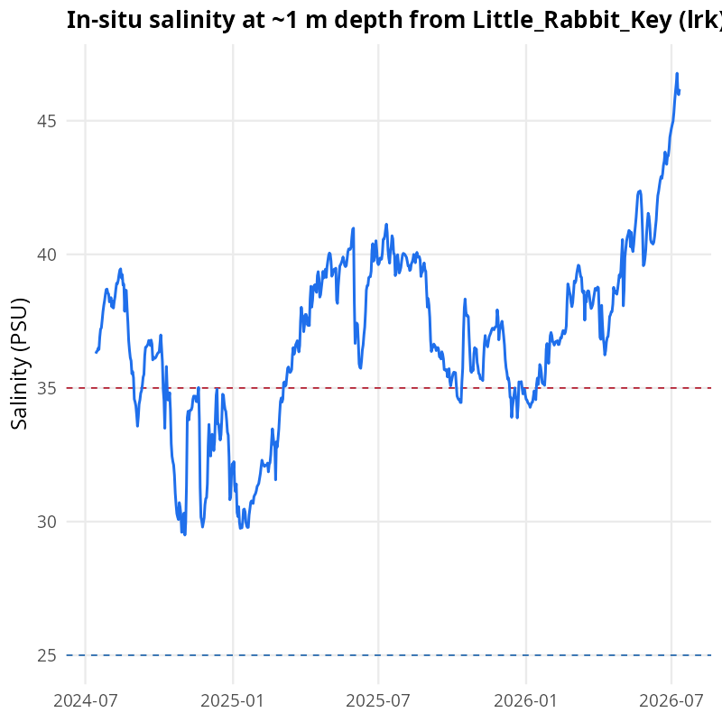

[Open Grafana panel](https://mbon-dashboards.marine.usf.edu/d-solo/cfraol6xev5kwd/south-florida-salinity?orgId=1&panelId=33&var-metric=mean&var-Buoy=Long_Sound%20%28lsn%29&from=1720965498428&to=1784037498428)

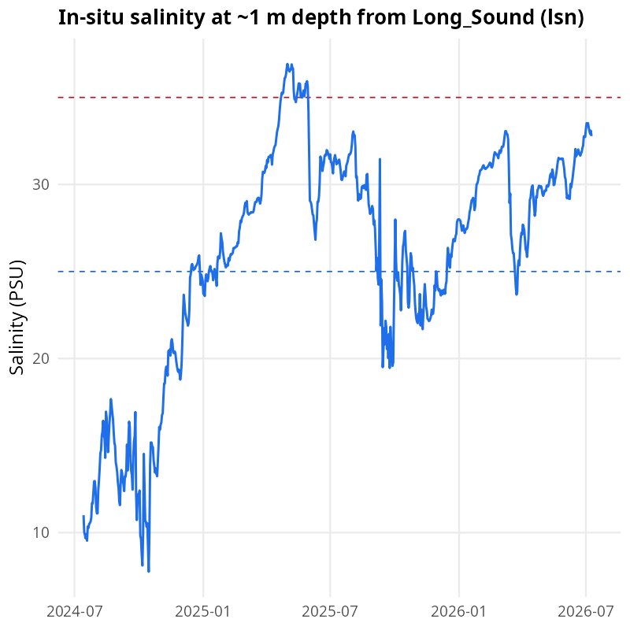

[Open Grafana panel](https://mbon-dashboards.marine.usf.edu/d-solo/cfraol6xev5kwd/south-florida-salinity?orgId=1&panelId=33&var-metric=mean&var-Buoy=Middle_Key%20%28mdk%29&from=1720965498428&to=1784037498428)

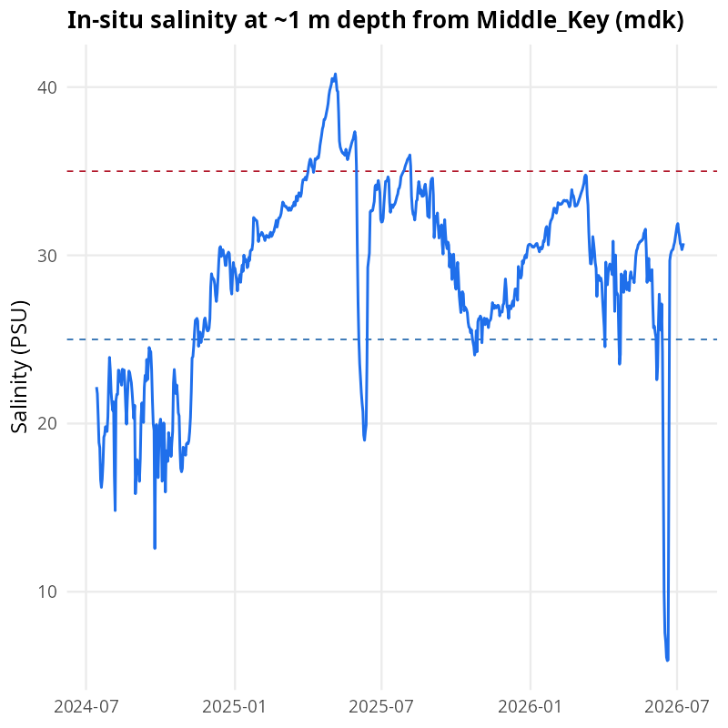

[Open Grafana panel](https://mbon-dashboards.marine.usf.edu/d-solo/cfraol6xev5kwd/south-florida-salinity?orgId=1&panelId=33&var-metric=mean&var-Buoy=Murray_Key%20%28muk%29&from=1720965498428&to=1784037498428)

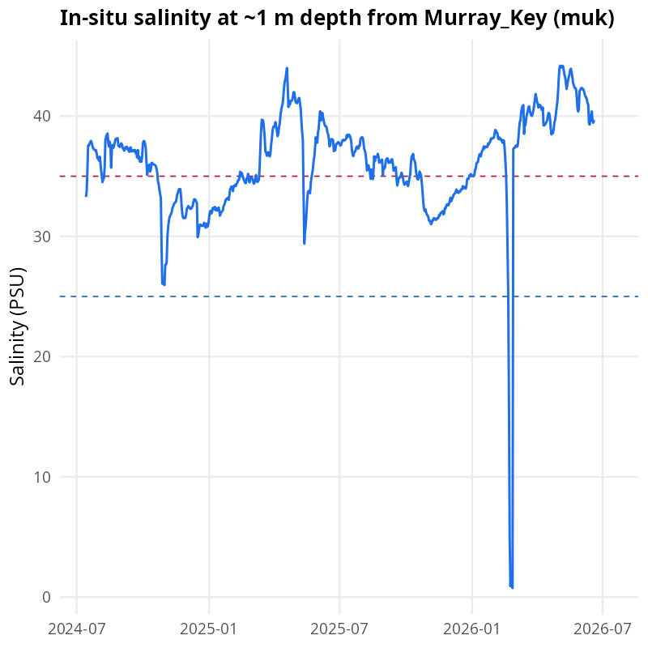

[Open Grafana panel](https://mbon-dashboards.marine.usf.edu/d-solo/cfraol6xev5kwd/south-florida-salinity?orgId=1&panelId=33&var-metric=mean&var-Buoy=Peterson_Key%20%28pky%29&from=1720965498428&to=1784037498428)

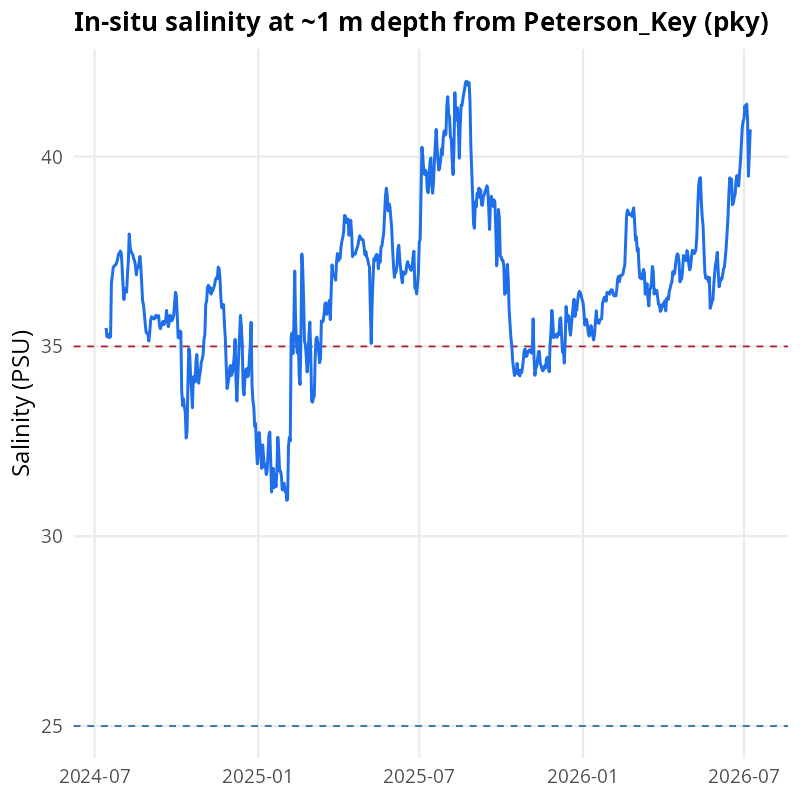

[Open Grafana panel](https://mbon-dashboards.marine.usf.edu/d-solo/cfraol6xev5kwd/south-florida-salinity?orgId=1&panelId=33&var-metric=mean&var-Buoy=Terrapin_Bay%20%28tby%29&from=1720965498428&to=1784037498428)

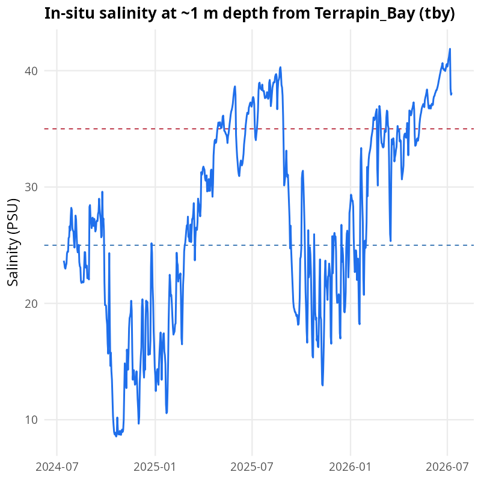

[Open Grafana panel](https://mbon-dashboards.marine.usf.edu/d-solo/cfraol6xev5kwd/south-florida-salinity?orgId=1&panelId=33&var-metric=mean&var-Buoy=Thursday_Point%20%28thr%29&from=1720965498428&to=1784037498428)

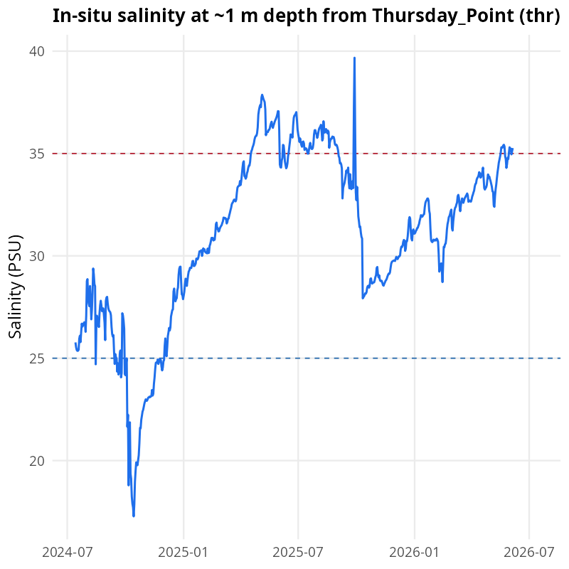

[Open Grafana panel](https://mbon-dashboards.marine.usf.edu/d-solo/cfraol6xev5kwd/south-florida-salinity?orgId=1&panelId=33&var-metric=mean&var-Buoy=Whipray_Basin%20%28wrb%29&from=1720965498428&to=1784037498428)

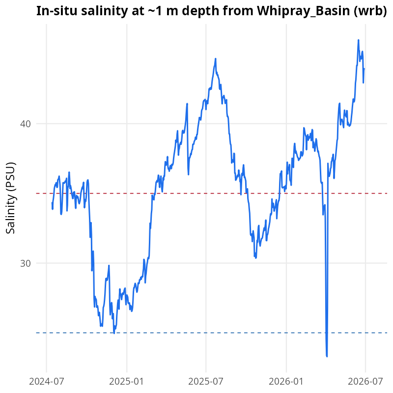

## Grafana links

- [Full South Florida Salinity dashboard](https://mbon-dashboards.marine.usf.edu/d/cfraol6xev5kwd/south-florida-salinity?orgId=1&from=1720965498428&to=1784037498428&var-metric=mean&viewPanel=panel-33)
- Panel ID: 33 on dashboard cfraol6xev5kwd

Grafana solo-panel iframes are not embedded here because the MBON server sets `X-Frame-Options: deny` and does not expose the image renderer plugin. Use the **Open Grafana panel** link on any chart to view the live Grafana panel for that buoy.